# Prática Ciência de Dados no R

Prática de ciência de dados no R em que serão respondidas algumas perguntas a respeito dos dados de vendas de eletrônicos ao longo de 12 meses.

Cada linha do data frame representa o item de uma compra que pode ou não conter mais itens; temos também a data e hora da compra, o valor do item e a quantidade comprada, além do endereço completo. Isso significa que linhas diferentes com o mesmo ID representam diferentes produtos que foram comprados simultâneamente, com entrega para um único endereço. Além disso, não deve haver linhas idênticas.

### Limpeza e organização

O primeiro passo é analisar o conteúdo das colunas para indentificar problemas.

```r
library(dplyr)
library(ggplot2)
library(dygraphs)
library(tidyverse)
library(hrbrthemes)
library(forcats)
library(viridis)
library(ggthemes)
library(lubridate)
library(xts)
```

```r
head(all_data,n=10)
```

|  | Order.ID | Product | Quantity.Ordered | Price.Each | Order.Date | Purchase.Address |
| --- | --- | --- | --- | --- | --- | --- |
| 1 | 176558 | USB-C Charging Cable | 2 | 11.95 | 04/19/19 08:46 | 917 1st St, Dallas, TX 75001 |
| 2 |  |  |  |  |  |  |
| 3 | 176559 | Bose SoundSport Headphones | 1 | 99.99 | 04/07/19 22:30 | 682 Chestnut St, Boston, MA 02215 |
| 4 | 176560 | Google Phone | 1 | 600 | 04/12/19 14:38 | 669 Spruce St, Los Angeles, CA 90001 |
| 5 | 176560 | Wired Headphones | 1 | 11.99 | 04/12/19 14:38 | 669 Spruce St, Los Angeles, CA 90001 |
| 6 | 176561 | Wired Headphones | 1 | 11.99 | 04/30/19 09:27 | 333 8th St, Los Angeles, CA 90001 |
| 7 | 176562 | USB-C Charging Cable | 1 | 11.95 | 04/29/19 13:03 | 381 Wilson St, San Francisco, CA 94016 |
| 8 | 176563 | Bose SoundSport Headphones | 1 | 99.99 | 04/02/19 07:46 | 668 Center St, Seattle, WA 98101 |
| 9 | 176564 | USB-C Charging Cable | 1 | 11.95 | 04/12/19 10:58 | 790 Ridge St, Atlanta, GA 30301 |
| 10 | 176565 | Macbook Pro Laptop | 1 | 1700 | 04/24/19 10:38 | 915 Willow St, San Francisco, CA 94016 |

```r
summary(all_data)
```

```
##      Order.ID                          Product              Quantity.Ordered
##          :   545   USB-C Charging Cable    :21903   1               :168552
##  Order ID:   355   Lightning Charging Cable:21658   2               : 13324
##  160873  :     5   AAA Batteries (4-pack)  :20641   3               :  2920
##  165665  :     4   AA Batteries (4-pack)   :20577   4               :   806
##  178158  :     4   Wired Headphones        :18882                   :   545
##  193511  :     4   Apple Airpods Headphones:15549   Quantity Ordered:   355
##  (Other) :185933   (Other)                 :67640   (Other)         :   348
##    Price.Each             Order.Date
##  11.95  :21903                 :   545
##  14.95  :21658   Order Date    :   355
##  2.99   :20641   12/15/19 20:16:     8
##  3.84   :20577   04/02/19 13:24:     7
##  11.99  :18882   10/30/19 21:28:     7
##  150    :15450   12/11/19 13:24:     7
##  (Other):67739   (Other)       :185921
##                                Purchase.Address
##                                        :   545
##  Purchase Address                      :   355
##  193 Forest St, San Francisco, CA 94016:     9
##  223 Elm St, Los Angeles, CA 90001     :     8
##  279 Sunset St, San Francisco, CA 94016:     8
##  176 North St, San Francisco, CA 94016 :     7
##  (Other)                               :185918
```

A função *summary* nos mostra alguns problemas: há linhas completamente vazias e outras preenchidas com o nome da respectiva variável.

O código abaixo remove as linhas vazias, em seguida as linhas preenchidas com o nome da coluna.

```r
#remove linhas vazias
dados = all_data[!apply(all_data == "", 1, all), ]

#remove linhas cujo valor da coluna Order.ID seja 'Order ID'
dados = subset(dados, Order.ID != 'Order ID')
```

As variáveis ‘Quantity.Ordered’ e ‘Price Each’ foram interpretados como fatores, elas devem ser convertidas para o formato numérico, mas antes, é necessário converter para o formato ‘character’ do R.

```r
dados$Quantity.Ordered = as.numeric(as.character(dados$Quantity.Ordered))
dados$Price.Each = as.numeric(as.character(dados$Price.Each))
```

Agora que os dados estão prontos para o uso, vamos chamar novamente a função *summary*.

```
##     Order.ID                          Product      Quantity.Ordered
##  160873 :     5   USB-C Charging Cable    :21903   Min.   :1.000
##  165665 :     4   Lightning Charging Cable:21658   1st Qu.:1.000
##  178158 :     4   AAA Batteries (4-pack)  :20641   Median :1.000
##  193511 :     4   AA Batteries (4-pack)   :20577   Mean   :1.124
##  194253 :     4   Wired Headphones        :18882   3rd Qu.:1.000
##  196615 :     4   Apple Airpods Headphones:15549   Max.   :9.000
##  (Other):185925   (Other)                 :66740
##    Price.Each               Order.Date
##  Min.   :   2.99   12/15/19 20:16:     8
##  1st Qu.:  11.95   04/02/19 13:24:     7
##  Median :  14.95   10/30/19 21:28:     7
##  Mean   : 184.40   12/11/19 13:24:     7
##  3rd Qu.: 150.00   01/17/19 21:54:     6
##  Max.   :1700.00   02/06/19 11:14:     6
##                    (Other)       :185909
##                                Purchase.Address
##  193 Forest St, San Francisco, CA 94016:     9
##  223 Elm St, Los Angeles, CA 90001     :     8
##  279 Sunset St, San Francisco, CA 94016:     8
##  176 North St, San Francisco, CA 94016 :     7
##  197 Center St, San Francisco, CA 94016:     7
##  284 Walnut St, San Francisco, CA 94016:     7
##  (Other)                               :185904
```

```
##                                          20in Monitor
##                          0                       4101
##     27in 4K Gaming Monitor           27in FHD Monitor
##                       6230                       7507
##     34in Ultrawide Monitor      AA Batteries (4-pack)
##                       6181                      20577
##     AAA Batteries (4-pack)   Apple Airpods Headphones
##                      20641                      15549
## Bose SoundSport Headphones              Flatscreen TV
##                      13325                       4800
##               Google Phone                     iPhone
##                       5525                       6842
##                   LG Dryer         LG Washing Machine
##                        646                        666
##   Lightning Charging Cable         Macbook Pro Laptop
##                      21658                       4724
##                    Product            ThinkPad Laptop
##                          0                       4128
##       USB-C Charging Cable            Vareebadd Phone
##                      21903                       2065
##           Wired Headphones
##                      18882
```

```
## 193 Forest St, San Francisco, CA 94016      223 Elm St, Los Angeles, CA 90001
##                                      9                                      8
## 279 Sunset St, San Francisco, CA 94016  176 North St, San Francisco, CA 94016
##                                      8                                      7
## 197 Center St, San Francisco, CA 94016 284 Walnut St, San Francisco, CA 94016
##                                      7                                      7
```

```
## [1] "Número total de produtos vendidos: 209079"
```

Alguns resultados interessantes:

- O produto mais vendido foi ‘USB-C Charging Cable’, com 21903 unidades vendidas;
- O item mais barato custou 2.99, e o mais caro, 1700 dólares;
- O preço médio de cada item foi 184,40 dólares.

É possível obter a quantidade de endereços diferentes registrada.

```
## [1] "Número de endereços: 140789"
```

E a distribuição do número de unidades de cada item na compra.

```
##      1      2      3      4      5      6      7      8      9
## 168552  13324   2920    806    236     80     24      5      3
```

A maioria absoluta dos produtos foi comprada como item único (168552), enquanto dois itens iguais foram pedidos em apenas 13324 vezes, caindo ainda mais para 2920 para 3 itens iguais na mesma compra.

### Quais dias do mês venderam mais?

Vamos agora utilizar o pacote lubridate que funciona da seguinte forma:

time = c(“2019-04-17”, “2019-01-23”) - **isto está no formato character**

ymd(time) - **isto está em formato de data**

A vantagem do formato de data do R, é que o ggplot (ferramenta gráfica) o reconhece automaticamente.

É necessário criar uma nova coluna com o valor total de cada linha como primeiro passo.

Note que a nova variável ‘Date’ é do tipo Date, e não factor ou character.

A função *xts* do pacote xts cria novo data frame que é indexado pelas datas. Em segida, a função *apply.daily*, do mesmo pacote, obtém a soma das vendas de cada dia.

```r
venda.data = xts(dados[, "Value"], order.by = dados$Date)

venda.data = apply.daily(venda.data, sum)
n= nrow(venda.data)

venda.data = venda.data[1:(n-1),]
```

[interactive chart not shown]

Também pode-se fazer um gráfico interativo da distribuição da evolução das vendas por dia.

[interactive chart not shown]

### Em que horas do dia foram registradas mais vendas?

É necessário extrair o horário da venda. Para isso, basta notar que a hora da compra são os caracteres 10 e 11 das célula de Order.Date

```r
dados$Hour = substr(as.character(dados$Order.Date), start=10,stop=11)
```

E então, as vendas são somadas segundo o horário em que ocorreram.

```r
#Valor total vendido para cada hora do dia
venda.hora=aggregate(Value ~Hour,
                    data=dados,FUN=sum)
```

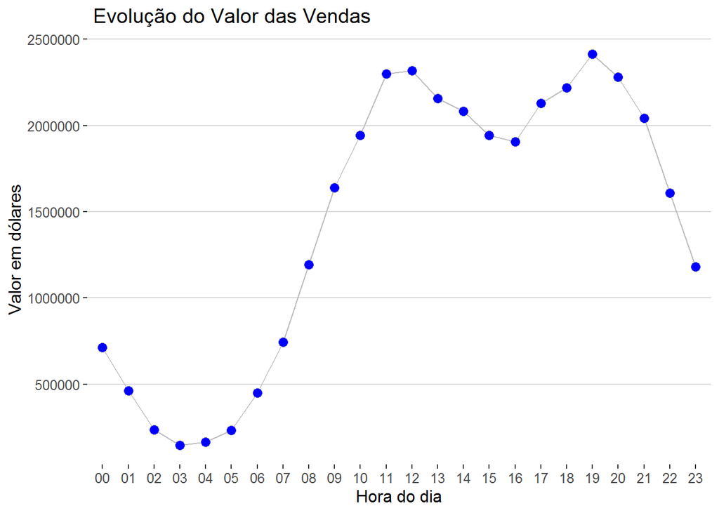

Compras no site foram realizadas com mais frequência entre 10h e 21h, atingindo picos as 12 e também as 19h.

### Qual cidade vendeu mais?

Deve-se extrair a cidade e o estado, pois há duas cidade com o mesmo nome em estados diferentes. Depois, basta aplicar a função *aggregate* novamente.

Agora, não é possível saber exatamente quais serão os índices a serem selecionados, pois os endereços não tem um formato padrão como hora e data. Então, vamos separar a string do endereço primeiro, utilizando a vírgula como separador para então selecionar a cidade e o estado.

```r
#strsplit retorna uma lista
city=  strsplit(as.character(dados$Purchase.Address), split = ',')

#convertendo para o formato vetor e selecionando apenas a cidade e o estado (a cidade é o segundo elemento e o estado são os caracteres 2 e 3 do terceiro elemento de cada objeto da lista)
city = unlist(lapply(city, function(x)  paste(x[2],substr(x[3],start=2,stop=3))))


dados$City = city
```

E após agrupar as vendas por cidade, pode-se obter o resultado na forma de um gráfico.

| City | Value |
| --- | --- |
| Atlanta GA | 2795498.6 |
| Austin TX | 1819581.8 |
| Boston MA | 3661642.0 |
| Dallas TX | 2767975.4 |
| Los Angeles CA | 5452570.8 |
| New York City NY | 4664317.4 |
| Portland ME | 449758.3 |
| Portland OR | 1870732.3 |
| San Francisco CA | 8262203.9 |
| Seattle WA | 2747755.5 |

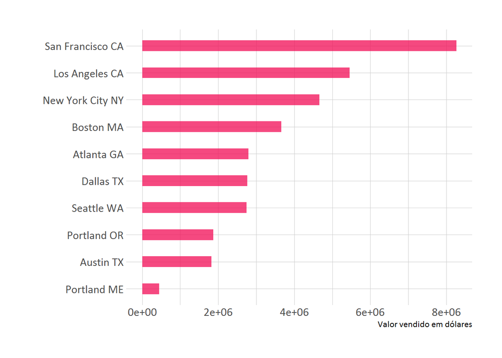

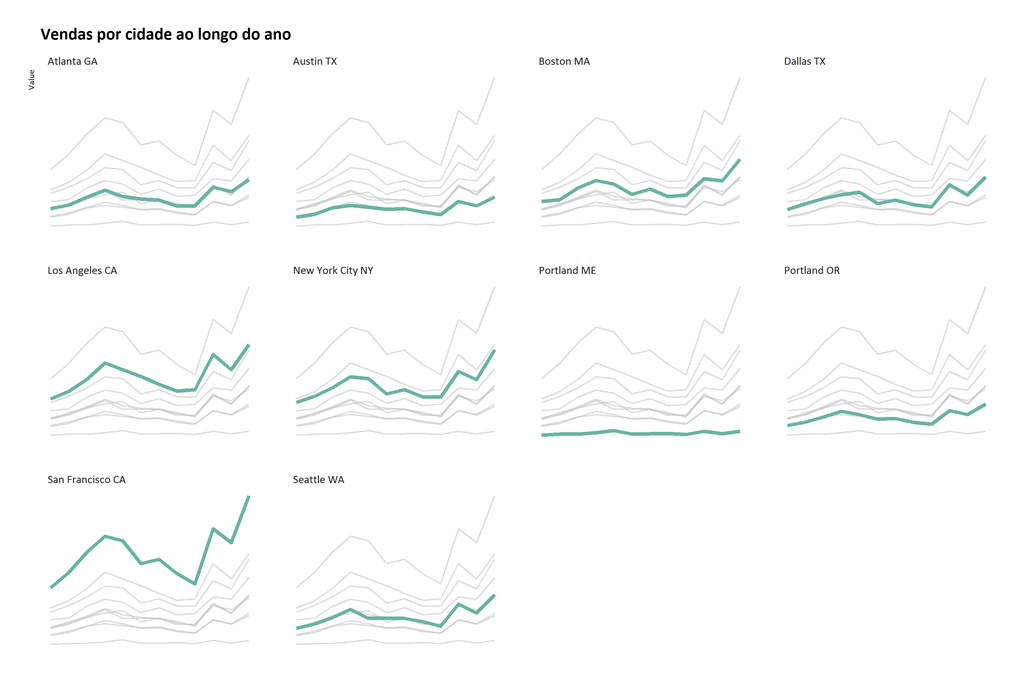

Observa-se o mesmo comportamento em todas as cidades: as vendas sobem de janeiro a abril e depois caem até o fim de setembro, antes de voltarem a subir rapidamente.

### Quais produtos são mais frequentemente vendidos juntos?

Primeiro, agrupam-se as vendas por ID e acrescenta-se os produtos. Mas antes é preciso verificar se existem linhas duplicadas:

```r
nrow(dados[duplicated(dados) | duplicated(dados, fromLast=TRUE),])
```

```
## [1] 528
```

Existem 528 linhas duplicadas.

```r
#remove linhas cujos IDs e Produtos sejam iguais e associa a um novo data frame

venda.id <-
  dados %>%
  distinct(Order.ID,Product, .keep_all=FALSE)
```

Agora, a função *count* do pacote dplyr cria um novo data frame com a frequência dos níveis.

|  | Order.ID | Product |
| --- | --- | --- |
| 1 | 176560 | Google Phone |
| 2 | 176560 | Wired Headphones |
| 3 | 176574 | Google Phone |
| 4 | 176574 | USB-C Charging Cable |
| 5 | 176586 | AAA Batteries (4-pack) |
| 6 | 176586 | Google Phone |

Note que agora todos os ID’s aparecem no mínimo duas vezes.

O código abaixo faz a contagem dos pares mais frequentes. *combn(unique(x), 2, paste, collapse=“-”)* encontra as combinações únicas dos produtos e os mostra juntos, *tapply* agrupa por ID e retorna uma lista, *unlist* transforma num vetor e *table* calcula as frequências de cada combinação. Essas frequências são sorteadas em ordem decrescente e *tail* seleciona as 5 maiores.

```r
teste=venda.id

results = tail(sort(table(unlist(tapply(as.character(teste$Product),
            teste$Order.ID, FUN=function(x) combn(unique(x), 2, paste,
            collapse=" e "))))),
           5)


(results)
```

```
##
## Vareebadd Phone e USB-C Charging Cable        Google Phone e Wired Headphones
##                                    361                                    413
##              iPhone e Wired Headphones    Google Phone e USB-C Charging Cable
##                                    447                                    985
##      iPhone e Lightning Charging Cable
##                                   1002
```

A tabela acima exibe os pares de produtos mais comumente vendidos juntos.